# PLPPM 5020: Temporal Progress

# 1 Libraries

First we need to run (and if necessary, install) some packages that we are going to use for these analyses

```r
# This code check if you have the package installed in R
if (!require(epifitter)) {
  install.packages("epifitter")
}

if (!require(ggthemes)) {
  install.packages("ggthemes")
}

if (!require(cowplot)) {
  install.packages("cowplot")
}
```

```r
# This code load the packages we'll be using
library(epifitter)
library(tidyverse)
library(ggthemes)

#This code set the graph theme we`ll be using throughout the script
theme_set(cowplot::theme_half_open())
```

# 2 Simulating disease progress curves

The `sim_` functions, regardless of the model, require the same set of six arguments. By default, at least two arguments are required (the others have default values)

- `r`: apparent infection rate
- `n`: number of replicates

When `n` is greater than one, replicated epidemics (e.g. replicated treatments) are produced and a level of noise (experimental error) should be set in the `alpha` argument. These two arguments combined set will generate `random_y` values, which will vary randomly across the defined number of replicates.

The other arguments are:

- `N`: epidemic duration in time units
- `dt`: time (fixed) in units between two assessments
- `y0`: initial inoculum
- `alpha`: noise parameters for the replicates

## 2.1 Models

### 2.1.1 Exponential

$$\frac{dy}{dt} = r_Ey$$

Let’s simulate a curve resembling the exponential growth.

#### 2.1.1.1 Simulation

```r
exp_data = sim_exponential(N = 100,      # Total time course of the epidemic
                           dt = 1,      # Time intervals
                           y0 = 0.01,   # Initial inoculum
                           r = 0.1,     # Apparent infection rate
                           n = 1,       # Number or replicates or sample size for each time step
                           alpha = 0.2  # Variation parameter
                           )
```

A `data.frame` object is produced with four columns:

- `replicates`: the curve with the respective ID number
- `time`: the assessment time
- `y`: the simulated proportion of disease intensity
- `random_y`: randomly simulated proportion disease intensity based on the noise

```r
exp_data
```

| replicates | time | y | random_y |
| --- | --- | --- | --- |
| 1 | 0 | 0.01000000 | 0.01118359 |
| 1 | 1 | 0.01105221 | 0.01000000 |
| 1 | 2 | 0.01221510 | 0.01016260 |
| 1 | 3 | 0.01350032 | 0.01434517 |
| 1 | 4 | 0.01492074 | 0.01566946 |
| 1 | 5 | 0.01649058 | 0.01202139 |
| 1 | 6 | 0.01822554 | 0.01646843 |
| 1 | 7 | 0.02014301 | 0.02043903 |
| 1 | 8 | 0.02226218 | 0.01726261 |
| 1 | 9 | 0.02460425 | 0.02900254 |

[output cut: 91 more lines]

##### 2.1.1.1.1 Graph

Use the [`ggplot2`](https://ggplot2.tidyverse.org/) package to build impressive graphics!

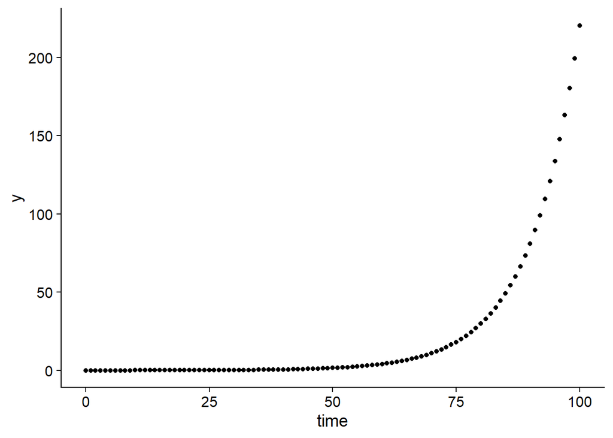

```r
exp_data %>%
  ggplot(aes(time, y)) +
  geom_point()
```

### 2.1.2 Monomolecular

$$\frac{dy}{dt} = r_M(K-y)$$

The logic is exactly the same here.

#### 2.1.2.1 Simulation

```r
mono_data = sim_monomolecular(N = 100,      # Total time course of the epidemic
                              dt = 1,      # Time intervals
                              y0 = 0.01,   # Initial inoculum
                              r = 0.1,     # Apparent infection rate
                              K = 1,       # Maximum asymptote
                              n = 1,       # Number or replicates or sample size for each time step
                              alpha = 0.2  # Variation parameter
                              )
mono_data
```

| replicates | time | y | random_y |
| --- | --- | --- | --- |
| 1 | 0 | 0.0100000 | 0.01069491 |
| 1 | 1 | 0.1042100 | 0.12403687 |
| 1 | 2 | 0.1894548 | 0.20313192 |
| 1 | 3 | 0.2665876 | 0.30350599 |
| 1 | 4 | 0.3363805 | 0.36051680 |
| 1 | 5 | 0.3995319 | 0.45333888 |
| 1 | 6 | 0.4566739 | 0.41071258 |
| 1 | 7 | 0.5083784 | 0.49396856 |
| 1 | 8 | 0.5551627 | 0.59716230 |
| 1 | 9 | 0.5974952 | 0.57262791 |

[output cut: 91 more lines]

#### 2.1.2.2 Graph

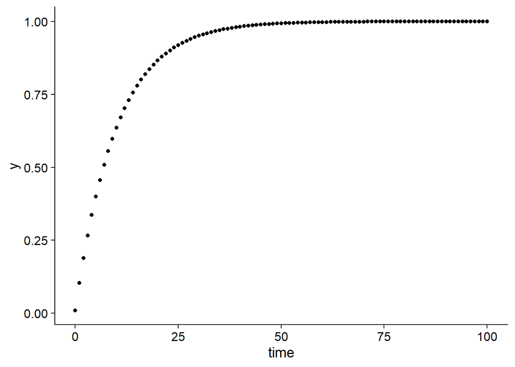

```r
mono_data %>%
  ggplot(aes(time, y)) +
  geom_point()
```

### 2.1.3 Logistic

$$\frac{dy}{dt} = yr_L(K-y)$$

#### 2.1.3.1 Simulation

```r
logi_data = sim_logistic(N = 100,      # Total time course of the epidemic
                         dt = 1,      # Time intervals
                         y0 = 0.01,   # Initial inoculum
                         r = 0.1,     # Apparent infection rate
                         K = 1,       # Maximum asymptote
                         n = 1,       # Number or replicates or sample size for each time step
                         alpha = 0.2  # Variation parameter
                         )
logi_data
```

| replicates | time | y | random_y |
| --- | --- | --- | --- |
| 1 | 0 | 0.01000000 | 0.01000000 |
| 1 | 1 | 0.01104058 | 0.01000000 |
| 1 | 2 | 0.01218808 | 0.01433976 |
| 1 | 3 | 0.01345318 | 0.01605822 |
| 1 | 4 | 0.01484760 | 0.01635585 |
| 1 | 5 | 0.01638413 | 0.01632115 |
| 1 | 6 | 0.01807671 | 0.01730613 |
| 1 | 7 | 0.01994056 | 0.01494286 |
| 1 | 8 | 0.02199226 | 0.01905373 |
| 1 | 9 | 0.02424979 | 0.02516191 |

[output cut: 91 more lines]

#### 2.1.3.2 Graph

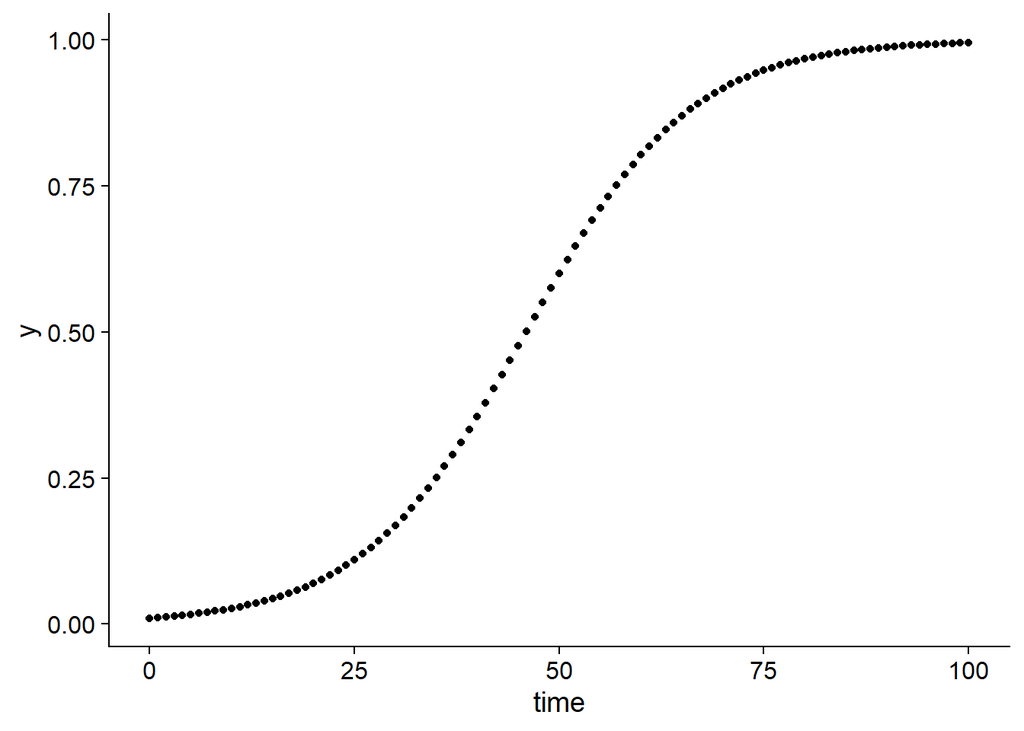

```r
logi_data %>%
  ggplot(aes(time, y)) +
  geom_point()
```

### 2.1.4 Gompertz

$$\frac{dy}{dt} = yr_G[ln(K)-ln(y)]$$

#### 2.1.4.1 Simulation

```r
gompi_data = sim_gompertz(N = 100,      # Total time course of the epidemic
                          dt = 1,      # Time intervals
                          y0 = 0.01,   # Initial inoculum
                          r = 0.1,     # Apparent infection rate
                          K = 1,       # Maximum asymptote
                          n = 1,       # Number or replicates or sample size for each time step
                          alpha = 0.2  # Variation parameter
                         )
gompi_data
```

| replicates | time | y | random_y |
| --- | --- | --- | --- |
| 1 | 0 | 0.01000000 | 0.01052919 |
| 1 | 1 | 0.01550021 | 0.01521307 |
| 1 | 2 | 0.02304401 | 0.02319268 |
| 1 | 3 | 0.03299052 | 0.03919003 |
| 1 | 4 | 0.04564475 | 0.05663198 |
| 1 | 5 | 0.06123129 | 0.04962890 |
| 1 | 6 | 0.07987485 | 0.07825001 |
| 1 | 7 | 0.10159022 | 0.10166352 |
| 1 | 8 | 0.12628664 | 0.10526655 |
| 1 | 9 | 0.15376997 | 0.17780659 |

[output cut: 91 more lines]

#### 2.1.4.2 Graph

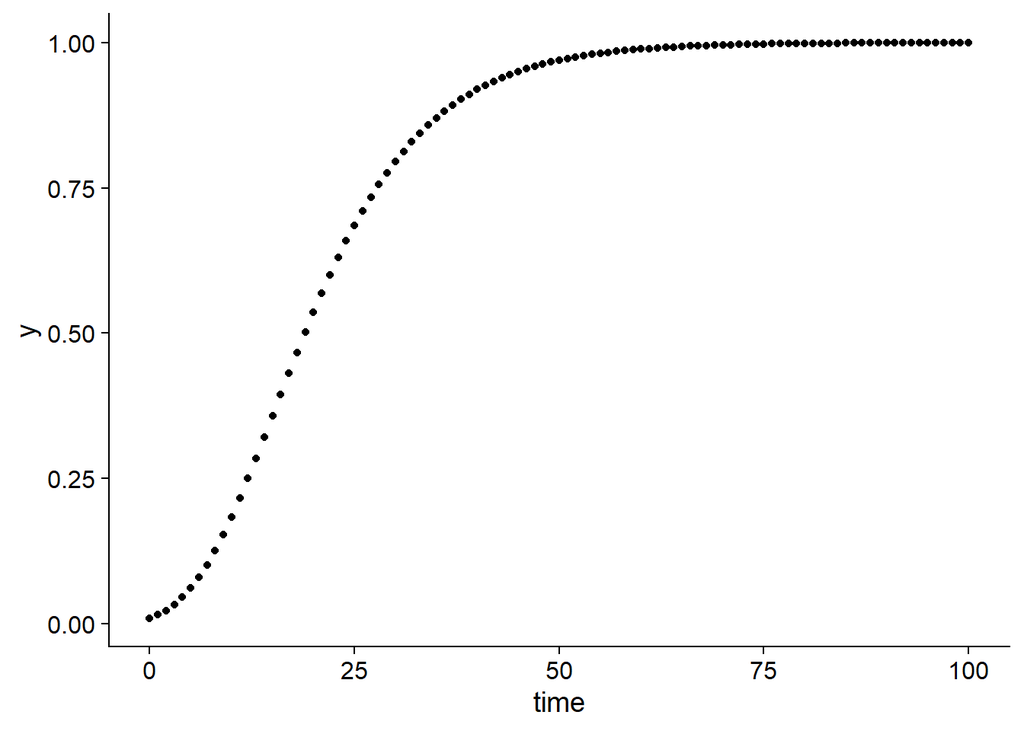

```r
gompi_data %>%
  ggplot(aes(time, y)) +
  geom_point()
```

### 2.1.5 Comparison

```r
data_models = bind_rows(Esponential = exp_data,
                        monomolecular = mono_data,
                        Logistic = logi_data,
                        Gompertz = gompi_data,
                        .id = "model")
```

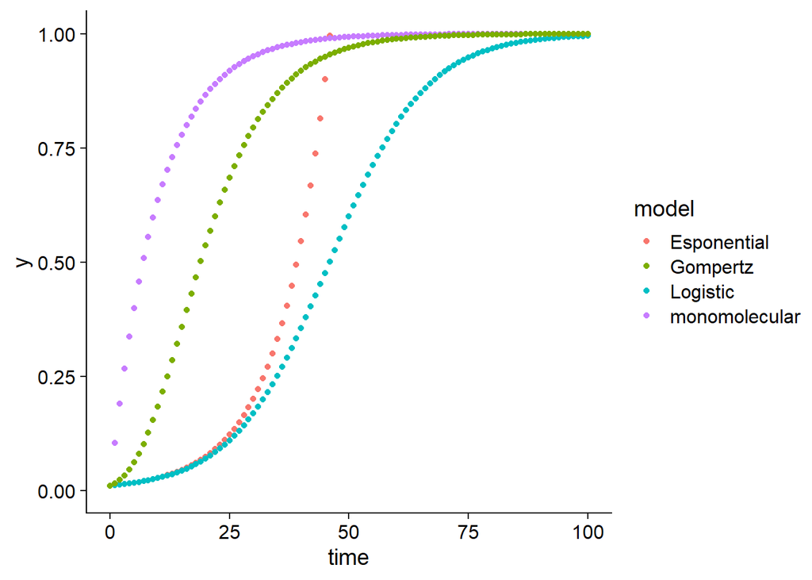

```r
data_models %>%
  ggplot(aes(time, y, color = model))+
  geom_point()+
  ylim(0,1)
```

## 2.2 Interact

[Click here](https://alvesks.shinyapps.io/simDPC/)

# 3 Fitting models

## 3.1 Data

```r
data("PowderyMildew")
PowderyMildew
```

|  | irrigation_type | moisture | block | time | sev |
| --- | --- | --- | --- | --- | --- |
| 1 | Drip | High moisture | 1 | 0 | 0.011 |
| 2 | Drip | High moisture | 2 | 0 | 0.011 |
| 3 | Drip | High moisture | 3 | 0 | 0.011 |
| 4 | Drip | High moisture | 1 | 7 | 0.034 |
| 5 | Drip | High moisture | 2 | 7 | 0.040 |
| 6 | Drip | High moisture | 3 | 7 | 0.036 |
| 7 | Drip | High moisture | 1 | 14 | 0.114 |
| 8 | Drip | High moisture | 2 | 14 | 0.109 |
| 9 | Drip | High moisture | 3 | 14 | 0.097 |
| 10 | Drip | High moisture | 1 | 21 | 0.126 |

[output cut: 230 more lines]

### 3.1.1 Visualization

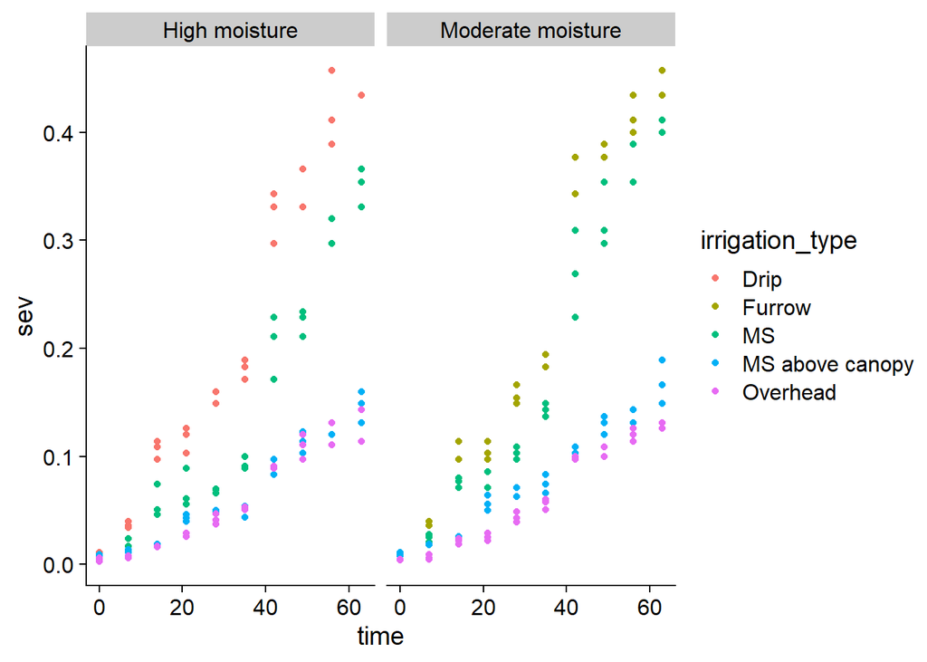

```r
PowderyMildew %>%
  ggplot(aes(time,sev, color = irrigation_type))+
  geom_point()+
  facet_wrap(~moisture)
```

## 3.2 One disease progress curve

### 3.2.1 Filter just one treatment

```r
single_curve = PowderyMildew %>%
  filter(irrigation_type == "Overhead",
         moisture == "Moderate moisture")
single_curve
```

|  | irrigation_type | moisture | block | time | sev |
| --- | --- | --- | --- | --- | --- |
| 211 | Overhead | Moderate moisture | 1 | 0 | 0.005 |
| 212 | Overhead | Moderate moisture | 2 | 0 | 0.005 |
| 213 | Overhead | Moderate moisture | 3 | 0 | 0.004 |
| 214 | Overhead | Moderate moisture | 1 | 7 | 0.009 |
| 215 | Overhead | Moderate moisture | 2 | 7 | 0.005 |
| 216 | Overhead | Moderate moisture | 3 | 7 | 0.006 |
| 217 | Overhead | Moderate moisture | 1 | 14 | 0.024 |
| 218 | Overhead | Moderate moisture | 2 | 14 | 0.019 |
| 219 | Overhead | Moderate moisture | 3 | 14 | 0.022 |
| 220 | Overhead | Moderate moisture | 1 | 21 | 0.029 |

[output cut: 20 more lines]

#### 3.2.1.1 Visualization

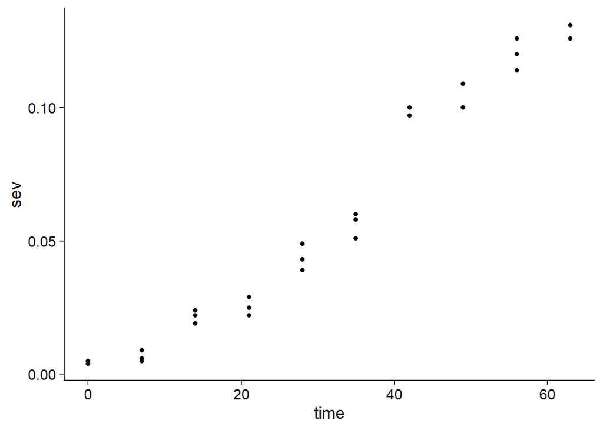

```r
single_curve %>%
  ggplot(aes(time, sev))+
  geom_point()
```

### 3.2.2 Fitting

### 3.2.3 Linear regression

```r
linear_fit = fit_lin(time = single_curve$time,
                     y = single_curve$sev)
linear_fit
```

```
## Results of fitting population models
##
## Stats:
##                  CCC r_squared    RSE
## Gompertz      0.9783    0.9576 0.0716
## Monomolecular 0.9758    0.9527 0.0110
## Logistic      0.9565    0.9167 0.3554
## Exponential   0.9522    0.9088 0.3577
##
##  Infection rate:
##                  Estimate    Std.error       Lower       Upper
## Gompertz      0.016352621 0.0006503022 0.015020538 0.015020538
## Monomolecular 0.002380123 0.0001002224 0.002174827 0.002174827
## Logistic      0.056648010 0.0032275707 0.050036631 0.050036631
## Exponential   0.054267887 0.0032481256 0.047614403 0.047614403
##
##  Initial inoculum:
##                   Estimate  Linearized      lin.SE        Lower        Upper
## Gompertz       0.005727317 -1.64142252 0.024301647  0.004400664  0.007359144
## Monomolecular -0.010716973 -0.01065995 0.003745287 -0.018500885 -0.002992548
## Logistic       0.006771091 -4.98829887 0.120613588  0.005296678  0.008652360
## Exponential    0.006890312 -4.97763892 0.121381718  0.005373488  0.008835304
```

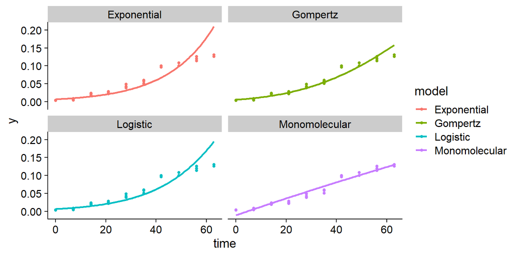

```r
plot_fit(linear_fit)
```

### 3.2.4 Non-linear regression

```r
nonlinear_fit = fit_nlin(time = single_curve$time,
                         y = single_curve$sev)
nonlinear_fit
```

```
## Results of fitting population models
##
## Stats:
##                  CCC r_squared    RSE
## Monomolecular 0.9749    0.9511 0.0105
## Gompertz      0.9728    0.9504 0.0107
## Logistic      0.9561    0.9254 0.0134
## Exponential   0.9509    0.9180 0.0141
##
##  Infection rate:
##                  Estimate    Std.error       Lower       Upper
## Monomolecular 0.002356965 0.0001013587 0.002149341 0.002149341
## Gompertz      0.013424949 0.0007563397 0.011875658 0.011875658
## Logistic      0.036867867 0.0027053672 0.031326173 0.031326173
## Exponential   0.033634386 0.0026042282 0.028299866 0.028299866
##
##  Initial inoculum:
##                  Estimate   Std.error        Lower        Upper
## Monomolecular -0.01006053 0.003660041 -0.017557786 -0.002563279
## Gompertz       0.01090815 0.001852706  0.007113058  0.014703249
## Logistic       0.01647854 0.002314498  0.011737500  0.021219570
## Exponential    0.01757848 0.002454890  0.012549862  0.022607090
```

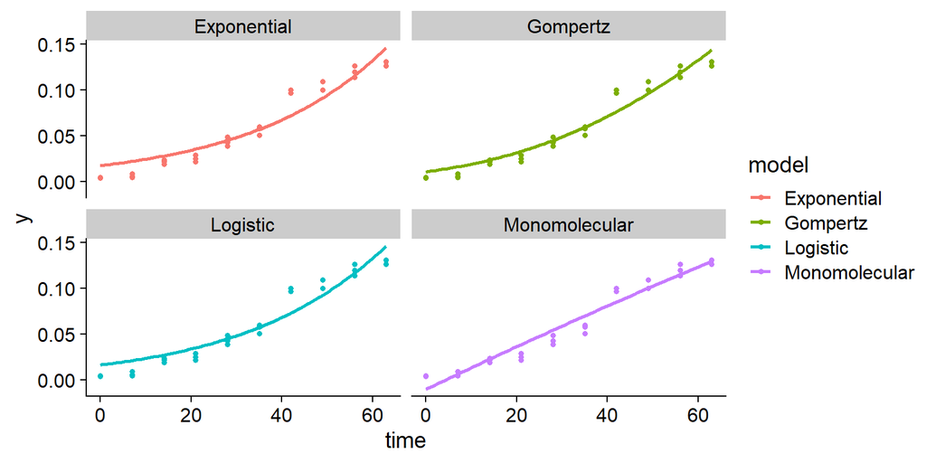

```r
plot_fit(nonlinear_fit)
```

### 3.2.5 Estimate maximun assimptote

```r
assimp_fit = fit_nlin2(time = single_curve$time,
                       y = single_curve$sev,
                       starting_par = list(y0 = 0.01, r = 0.03, K = 0.2))
assimp_fit
```

```
## Results of fitting population models
##
## Stats:
##                  CCC r_squared    RSE
## Logistic      0.9922    0.9844 0.0060
## Gompertz      0.9898    0.9798 0.0069
## Monomolecular 0.9749    0.9511 0.0107
##
##  Infection rate:
##                  Estimate   Std.error        Lower        Upper
## Logistic      0.094681988 0.007270294  0.079764577  0.079764577
## Gompertz      0.045161968 0.005920228  0.033014663  0.033014663
## Monomolecular 0.002356965 0.004942440 -0.007784084 -0.007784084
##
##  Initial inoculum:
##                   Estimate    Std.error        Lower         Upper
## Logistic       0.004332181 0.0009216084  0.002441197  6.223165e-03
## Gompertz       0.001632761 0.0009442134 -0.000304605  3.570127e-03
## Monomolecular -0.010060535 0.0048853314 -0.020084407 -3.666291e-05
##
##  Maximum disease intensity:
##                Estimate   Std.error      Lower     Upper
## Logistic      0.1400095 0.005476538  0.1287726 0.1512464
## Gompertz      0.1738265 0.016317225  0.1403463 0.2073067
## Monomolecular 1.0000000 1.968181653 -3.0383752 5.0383752
```

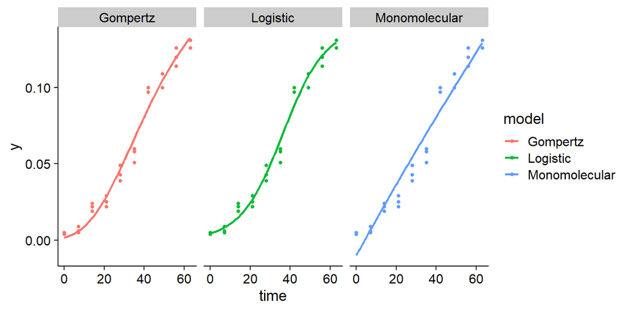

```r
plot_fit(assimp_fit)
```

## 3.3 Multiple DPCs

```r
fit_pd = fit_multi(time_col = "time",
          intensity_col = "sev",
          strata_cols = c("irrigation_type", "moisture"),
          estimate_K = T,
          nlin = T,
          data = PowderyMildew)
```

### 3.3.1 Model parameters

```r
fit_pd$Parameters
```

| irrigation_type | moisture | model | y0 | y0_se | r | r_se | K | K_se | df | CCC | r_squared | RSE | y0_ci_lwr | y0_ci_upr | r_ci_lwr | r_ci_upr | K_ci_lwr | K_ci_upr | best_model |
| --- | --- | --- | --- | --- | --- | --- | --- | --- | --- | --- | --- | --- | --- | --- | --- | --- | --- | --- | --- |
| Drip | High moisture | Gompertz | 0.018849579 | 0.0071110926 | 0.033067648 | 0.006140746 | 0.7116518 | 0.12563295 | 27 | 0.9833178 | 0.9671276 | 0.028503244 | 4.258823e-03 | 3.344034e-02 | 0.020467879 | 0.04566742 | 0.453874253 | 0.9694293 | 1 |
| Drip | High moisture | Logistic | 0.050458366 | 0.0099033736 | 0.045476149 | 0.008384517 | 1.0000000 | 0.44443086 | 27 | 0.9717192 | 0.9480437 | 0.036391954 | 3.013832e-02 | 7.077841e-02 | 0.028272541 | 0.06267976 | 0.088103202 | 1.9118968 | 2 |
| Drip | High moisture | Monomolecular | -0.028414128 | 0.0188727048 | 0.009020758 | 0.005867130 | 1.0000000 | 0.50985512 | 27 | 0.9659776 | 0.9352272 | 0.040065379 | -6.713772e-02 | 1.030946e-02 | -0.003017598 | 0.02105911 | -0.046136303 | 2.0461363 | 3 |
| MS | High moisture | Gompertz | 0.007833778 | 0.0043887768 | 0.024512439 | 0.006876443 | 1.0000000 | 0.45684018 | 27 | 0.9825038 | 0.9654614 | 0.022901949 | -1.171248e-03 | 1.683880e-02 | 0.010403144 | 0.03862173 | 0.062641371 | 1.9373586 | 1 |
| MS | High moisture | Logistic | 0.022105801 | 0.0052987297 | 0.051679450 | 0.008331668 | 1.0000000 | 0.58577139 | 27 | 0.9800223 | 0.9620188 | 0.024127185 | 1.123371e-02 | 3.297790e-02 | 0.034584280 | 0.06877462 | -0.201903611 | 2.2019036 | 2 |
| MS | High moisture | Monomolecular | -0.038324474 | 0.0202037350 | 0.006203798 | 0.008383420 | 1.0000000 | 1.16097071 | 27 | 0.9324814 | 0.8756670 | 0.043370655 | -7.977911e-02 | 3.130166e-03 | -0.010997558 | 0.02340515 | -1.382115130 | 3.3821151 | 3 |
| MS | Moderate moisture | Gompertz | 0.006642632 | 0.0044769629 | 0.035156083 | 0.007314911 | 0.7053840 | 0.15003212 | 27 | 0.9825371 | 0.9655249 | 0.028191586 | -2.543337e-03 | 1.582860e-02 | 0.020147125 | 0.05016504 | 0.397543478 | 1.0132244 | 1 |
| MS | Moderate moisture | Logistic | 0.033019547 | 0.0082356463 | 0.050421715 | 0.009283154 | 1.0000000 | 0.50204557 | 27 | 0.9723190 | 0.9489517 | 0.034637119 | 1.612140e-02 | 4.991770e-02 | 0.031374257 | 0.06946917 | -0.030112413 | 2.0301124 | 2 |
| MS | Moderate moisture | Monomolecular | -0.044666408 | 0.0225930192 | 0.008107436 | 0.007506181 | 1.0000000 | 0.75690399 | 27 | 0.9455453 | 0.8987336 | 0.048134489 | -9.102345e-02 | 1.690638e-03 | -0.007293975 | 0.02350885 | -0.553038706 | 2.5530387 | 3 |
| Furrow | Moderate moisture | Gompertz | 0.012886768 | 0.0062540049 | 0.039206395 | 0.006646530 | 0.6456778 | 0.08731399 | 27 | 0.9834864 | 0.9673484 | 0.029846442 | 5.460983e-05 | 2.571893e-02 | 0.025568842 | 0.05284395 | 0.466524258 | 0.8248313 | 1 |

[output cut: 14 more lines]

### 3.3.2 Model data

```r
fit_pd$Data
```

| irrigation_type | moisture | time | y | model | predicted | residual |
| --- | --- | --- | --- | --- | --- | --- |
| Drip | High moisture | 0 | 0.011 | Logistic | 0.050458366 | -3.945837e-02 |
| Drip | High moisture | 0 | 0.011 | Logistic | 0.050458366 | -3.945837e-02 |
| Drip | High moisture | 0 | 0.011 | Logistic | 0.050458366 | -3.945837e-02 |
| Drip | High moisture | 7 | 0.034 | Logistic | 0.068084170 | -3.408417e-02 |
| Drip | High moisture | 7 | 0.040 | Logistic | 0.068084170 | -2.808417e-02 |
| Drip | High moisture | 7 | 0.036 | Logistic | 0.068084170 | -3.208417e-02 |
| Drip | High moisture | 14 | 0.114 | Logistic | 0.091275071 | 2.272493e-02 |
| Drip | High moisture | 14 | 0.109 | Logistic | 0.091275071 | 1.772493e-02 |
| Drip | High moisture | 14 | 0.097 | Logistic | 0.091275071 | 5.724929e-03 |
| Drip | High moisture | 21 | 0.126 | Logistic | 0.121336781 | 4.663219e-03 |

[output cut: 710 more lines]

### 3.3.3 Visualization

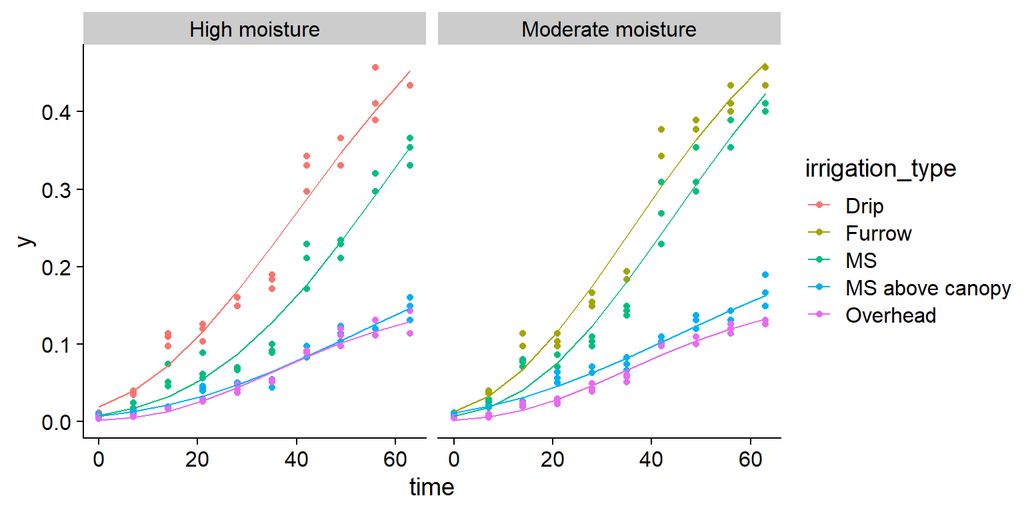

```r
fit_pd$Data %>%
  filter(model == "Gompertz") %>%
  ggplot()+
  geom_point(aes(time, y, color= irrigation_type))+
  geom_line(aes(time, predicted, color= irrigation_type))+
  facet_wrap(~moisture)
```

# 4 Area under disease progress curves

## 4.1 Single DPC

```r
AUDPC(time = single_curve$time,
      y = single_curve$sev)
```

```
## [1] 3.8815
```

## 4.2 Multiple DPCs

```r
PowderyMildew %>%
  group_by(irrigation_type, moisture,block ) %>%
  summarise(audpc = AUDPC(time = time, y = sev),
            audps = AUDPS(time = time, y = sev))
```

| irrigation_type | moisture | block | audpc | audps |
| --- | --- | --- | --- | --- |
| Drip | High moisture | 1 | 12.9955 | 14.553 |
| Drip | High moisture | 2 | 13.8845 | 15.442 |
| Drip | High moisture | 3 | 13.2895 | 14.847 |
| Furrow | Moderate moisture | 1 | 13.5275 | 15.162 |
| Furrow | Moderate moisture | 2 | 14.0035 | 15.638 |
| Furrow | Moderate moisture | 3 | 13.8670 | 15.421 |
| MS | High moisture | 1 | 8.0605 | 9.359 |
| MS | High moisture | 2 | 9.2435 | 10.507 |
| MS | High moisture | 3 | 8.2565 | 9.443 |
| MS | Moderate moisture | 1 | 10.5210 | 11.991 |

[output cut: 14 more lines]

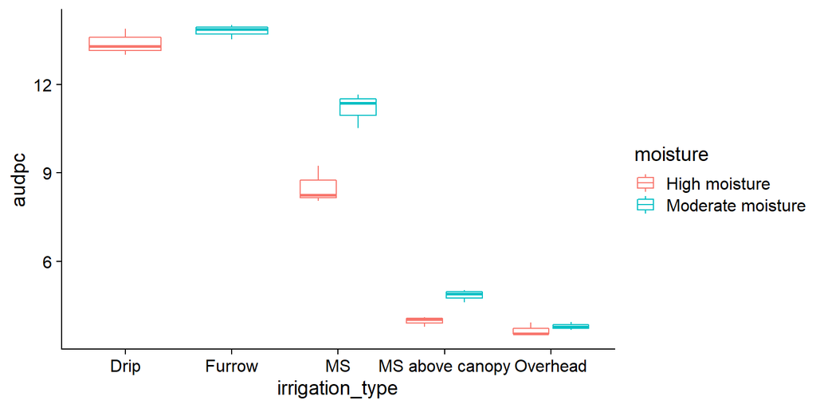

```r
PowderyMildew %>%
  group_by(irrigation_type, moisture,block ) %>%
  summarise(audpc = AUDPC(time = time, y = sev),
            audps = AUDPS(time = time, y = sev)) %>%
  ggplot(aes(irrigation_type, audpc, color = moisture)) +
  geom_boxplot()
```

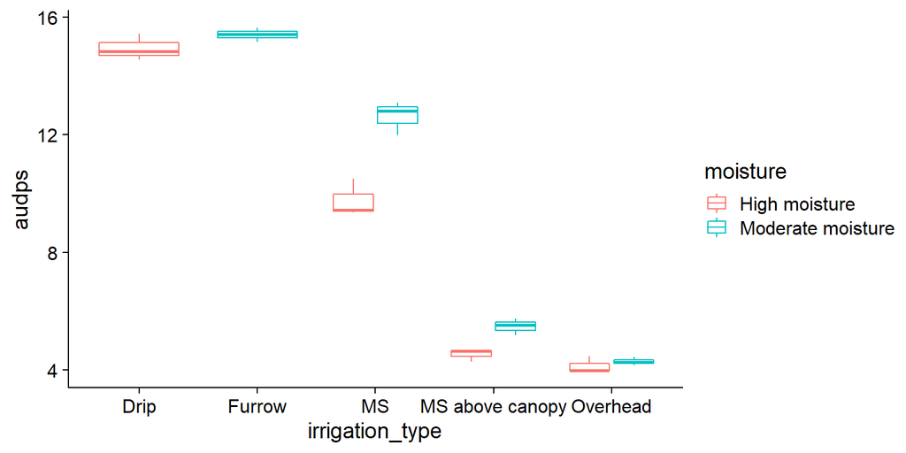

```r
PowderyMildew %>%
  group_by(irrigation_type, moisture,block ) %>%
  summarise(audpc = AUDPC(time = time, y = sev),
            audps = AUDPS(time = time, y = sev)) %>%
  ggplot(aes(irrigation_type, audps, color = moisture)) +
  geom_boxplot()
```